# Final_Exam

Lemar Popal

March 21, 2019

```r
library(tidyverse)
library(lubridate)
library(broom)
library(modelr)
```

```r
nutrition <- read.csv("https://dropbox.com/s/ucwls7j3zlb5sas/cereal.csv?dl=1")
```

# Part One

```r
adjust_cereal <- function(measurement, num_cups, weight, string) {
  if (string == "volume") {
    return(measurement/num_cups)
  }
  else if (string == "weight") {
    return(measurement/weight)
  }
}
```

```r
cols = c("calories", "protein", "fat", "sodium", "fiber", "carbo", "sugars", "potass")

nutrition <- nutrition %>%
  mutate(
    calories = adjust_cereal(calories, cups, weight, "volume"),
    protein = adjust_cereal(protein, cups, weight, "volume"),
    fat = adjust_cereal(fat, cups, weight, "volume"),
    sodium = adjust_cereal(sodium, cups, weight, "volume"),
    fiber = adjust_cereal(fiber, cups, weight, "volume"),
    carbo = adjust_cereal(carbo, cups, weight, "volume"),
    sugars = adjust_cereal(sugars, cups, weight, "volume"),
    potass = adjust_cereal(potass, cups, weight, "volume")
  )

### see if there is a better way of doing this without code repetition
```

# Part Two

```r
nutrition <- nutrition %>%
  mutate(
    Seed_Type = as.factor(case_when(
      # str_extract will extract the first matching word
      str_extract(tolower(name), "wheat|oat|bran") == "wheat" ~ "wheat",
      str_extract(tolower(name), "wheat|oat|bran") == "oat" ~ "oat",
      str_extract(tolower(name), "wheat|oat|bran") == "bran" ~ "bran",
      TRUE ~ "unknown"
    )
  ))

# reordering the factor levels
levels(nutrition$Seed_Type) <- c("wheat", "oat", "bran", "unknown")
```

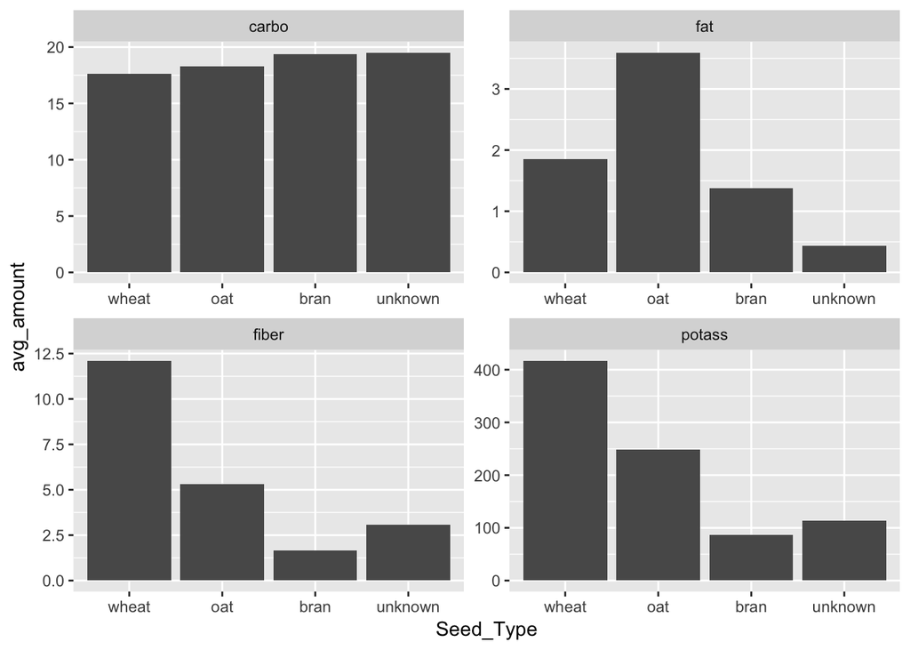

```r
nutrition %>%
  gather(key = "substance", value = "amount", cols) %>%
  group_by(Seed_Type, substance) %>%
  summarise(avg_amount = mean(amount)) %>%
  ungroup() %>%
  filter(substance %in% c("carbo", "fat", "fiber", "potass")) %>%
  ggplot(aes(x=Seed_Type, y=avg_amount)) + geom_col() + facet_wrap(~ substance, scales="free")
```

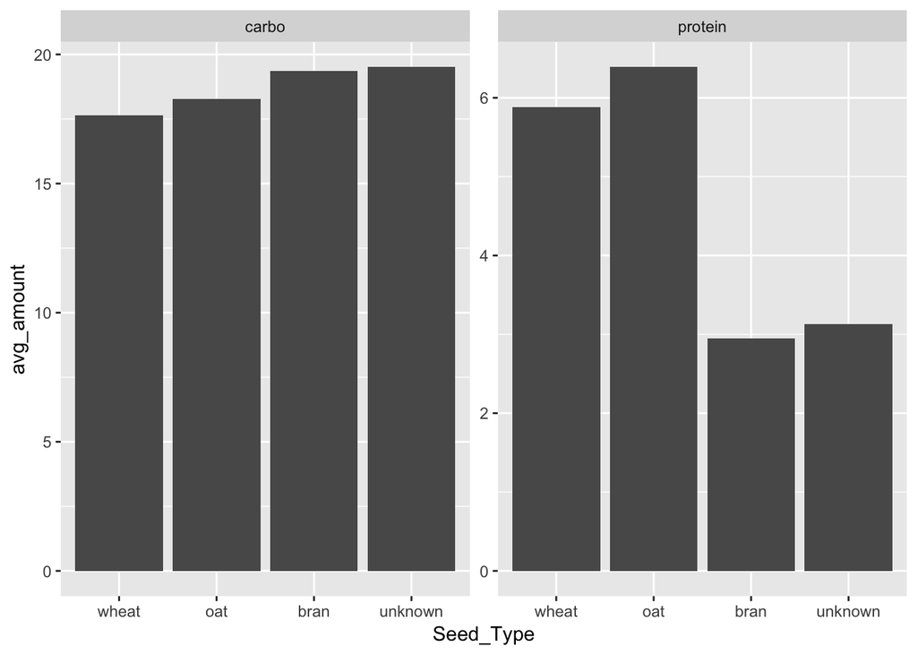

```r
nutrition %>%
  gather(key = "substance", value = "amount", cols) %>%
  group_by(Seed_Type, substance) %>%
  summarise(avg_amount = mean(amount)) %>%
  ungroup() %>%
  filter(substance %in% c("carbo", "protein")) %>%
  ggplot(aes(x=Seed_Type, y=avg_amount)) + geom_col() + facet_wrap(~ substance, scales="free")
```

From the plot above, we can see that oats are low in average carbs and the highest in average protein per serving.

```r
# sugars has already been adjusted to serving size is per cup
nrow(nutrition %>% filter(sugars < 6))
```

```
## [1] 26
```

You would only be allowd to eat 26 of the cereals in the dataset.

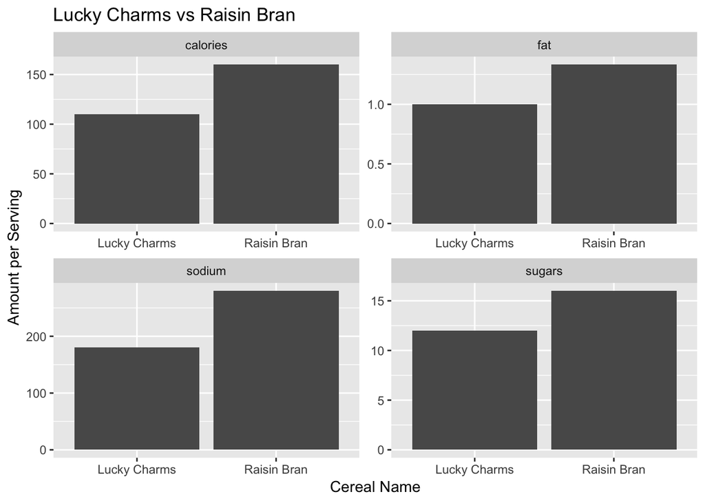

```r
cereals = c("Lucky Charms", "Raisin Bran")
substances = c("calories", "fat", "sodium", "sugars")

nutrition %>%
  filter(name %in% cereals) %>%
  gather(key = "substance", value = "amount", cols) %>%
  filter(substance %in% substances) %>%
  ggplot(aes(x=name, y=amount)) + geom_col() + facet_wrap(~ substance, scales="free") +
  xlab("Cereal Name") + ylab("Amount per Serving") + ggtitle("Lucky Charms vs Raisin Bran")
```

# Part Three

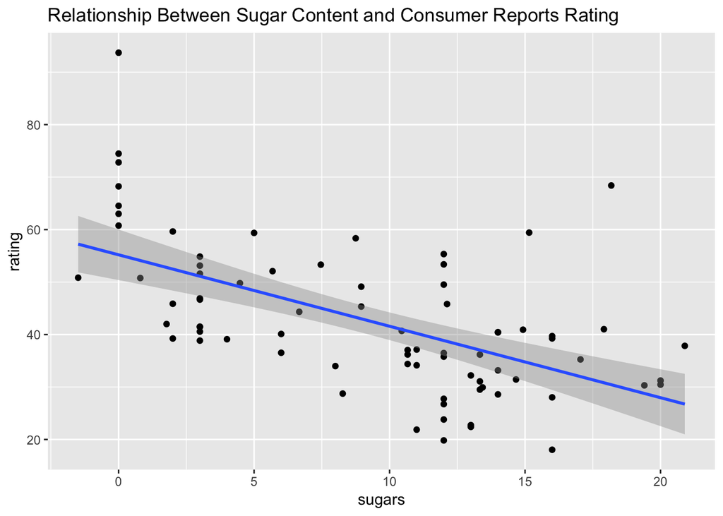

```r
nutrition %>%
  ggplot(aes(x=sugars, y=rating)) + geom_point() + stat_smooth(method="lm") +
  ggtitle("Relationship Between Sugar Content and Consumer Reports Rating")
```

```r
tidy(summary(lm(rating ~ sugars, data=nutrition)))
```

```
## # A tibble: 2 x 5
##   term        estimate std.error statistic  p.value
##   <chr>          <dbl>     <dbl>     <dbl>    <dbl>
## 1 (Intercept)    55.2      2.42      22.8  1.72e-35
## 2 sugars         -1.36     0.221     -6.17 3.21e- 8
```

From the output of the linear model summary above, we see that there is a negative correlation between the amount of sugars and the rating given by Consumer Reports. This linear model is statistically significant because the p.value is less than 0.05.

```r
# get vector of ratings for General Mills
g_ratings <- nutrition %>%
  filter(mfr == "G") %>%
  pull(rating)

# get vector of ratings for Kellog
k_ratings <- nutrition %>%
  filter(mfr == "K") %>%
  pull(rating)
```

```r
tidy(t.test(k_ratings, g_ratings, alternative="greater"))
```

```
## # A tibble: 1 x 10
##   estimate estimate1 estimate2 statistic p.value parameter conf.low
##      <dbl>     <dbl>     <dbl>     <dbl>   <dbl>     <dbl>    <dbl>
## 1     9.55      44.0      34.5      2.68 0.00550      36.9     3.53
## # … with 3 more variables: conf.high <dbl>, method <chr>,
## #   alternative <chr>
```

My null hypothesis is that the average rating of cereals between the two brands is equal, and my alternative is that the Kellog receives higher ratings. We are allowed to use the t-test because we consider the cereals in the dataset to be a random sample of all cereals offered by the two manufacturers, they are independent, and the ratings are normal. The p.value is less than 0.05, so we can reject the null hypothesis and conclude that we are 95% confident Kellog receives higher ratings than GM.

```r
nutrition %>%
  filter(mfr == "K" | mfr == "G") %>%
  group_by(mfr) %>%
  summarise(percent_good = mean(rating > 50) * 100)
```

```
## # A tibble: 2 x 2
##   mfr   percent_good
##   <fct>        <dbl>
## 1 G             9.09
## 2 K            26.1
```

Kellog has a higher percent of good cereals in this data set.

```r
set.seed(37)
kellog_boots <- replicate(1000, sample(k_ratings, replace = TRUE), simplify = FALSE)

gm_boots <- replicate(1000, sample(g_ratings, replace = TRUE), simplify = FALSE)
```

```r
kellog_good_cereals = map_dbl(kellog_boots, ~sum(. > 50))
gm_good_cereals = map_dbl(gm_boots, ~sum(. > 50))
```

```r
sum(unlist(map(kellog_good_cereals > gm_good_cereals, as.integer)))
```

```
## [1] 914
```

914 of 1000 times, Kellog has more good cereals than General Mills. The difference I saw in (b) is not statistically significant, because Kellog had more good cereals than GM only 91.4% of the time. We cannot quite be 95% confident that Kellog Cereals have a higher percent of good cereals.